# Kolokwium 31.01.2023 - zadanie 3

Do zadań należy wykorzystać zbiór danych `Sacramento` z biblioteki `caret`. Zawiera on 932 obserwacji 9 zmiennych opisujących różne parametry domów na sprzedaż w Kaliforni. Przed przystąpienie do zadań należy zapoznać się ze zbiorem w zakładce Help.

**1. (1 pkt.)** Sprawdź czy możliwe jest wykluczenie którejś ze zmiennych kategorycznych ze względu na dominację w niej jednego z poziomów (powyżej 90%). Jeśli tak to pozostaw tylko rekordy z dominującą wartością zmiennej, a następnie usuń tę kolumnę ze zbioru. Wykorzystaj do tego zadania funkcję `summary()` oraz operator potoku.

**2. (2 pkt.)** Wykonaj kilka wariantów regresji liniowej traktując kolumnę `price` jako zmienną wynikową:

- wariant 1: wszystkie pozostałe zmienne są predyktorami,
- wariant 2: bez zmiennej `zip`,
- wariant 3: bez zmiennej `city`,
- wariant 4: bez zmiennych `zip` oraz `city`.

Przeanalizuj uzyskane warianty regresji liniowej i na tej podstawie wybierz zmienne do modelu predykcyjnego. Uzasadnij swój wybór w komentarzu.

**3. (2 pkt.)** Zbuduj model regresyjny oparty na zmiennych wybranych w pkt. 2 i wykonaj przy jego pomocy predykcję ceny. Do predykcji użyj tych samych danych co do trenowania modelu. Zapisz wynik predykcji jako nową kolumnę w ramce z danymi. Oblicz i wyświetl co najmniej dwie miary skuteczności modelu.

```
## [1] "RMSE =  79561.8"
```

```
## [1] "MAE =  57805.2"
```

**4. (1 pkt.)** Wykonaj wykres punktowy w pakiecie `ggplot2`, przedstawiający zależność ceny przewidzianej przez model od ceny rzeczywistej. Dla lepszej wizualizacji różnic między predykcją a rzeczywistością dodaj do wykresu prostą `y=price` w kolorze czerwonym. Podpisz osie.

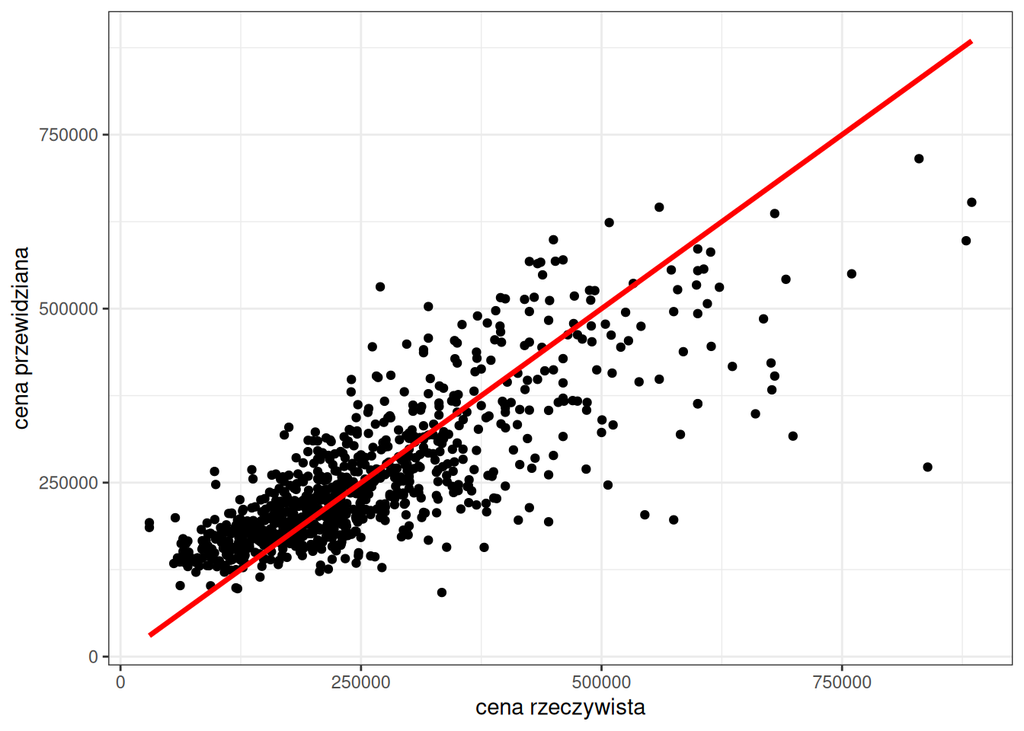